# Shab-Analyse

Claudio Lutz

2024-07-28

## Einführung

### HR01

Dieser Code wird für die Registrierung neuer Unternehmen im Handelsregister verwendet. Wenn ein neues Unternehmen gegründet und registriert wird, erfolgt die Veröffentlichung unter HR01. Dies umfasst Details wie den Firmennamen, den Sitz, den Zweck und die Namen der Verwaltungsratsmitglieder oder Geschäftsführer.

### HR03

Dieser Code bezieht sich auf die Löschung eines Unternehmens aus dem Handelsregister. Dies geschieht, wenn ein Unternehmen aufgelöst, liquidiert oder anderweitig nicht mehr als registrierte Einheit existiert. Die Löschung muss beantragt werden, wenn beispielsweise ein Einzelunternehmen nicht mehr existiert oder an eine andere Person übergeht.

Weitere Informationen zu den Eintragungspflichten und -verfahren befinden sich auf folgender Seite:

- [Handelsregister: Rechte und Pflichten für KMU](https://www.kmu.admin.ch/kmu/de/home/praktisches-wissen/kmu-gruenden/firmengruendung/handelsregister.html)

```r
#Change eval=TRUE if packages need to be installed

if (!require(tidyr)) install.packages("tidyr")
if (!require(httr)) install.packages("httr")
if (!require(XML)) install.packages("XML")
if (!require(dplyr)) install.packages("dplyr")
if (!require(ggplot2)) install.packages("ggplot2")
if (!require(gridExtra)) install.packages("gridExtra")
if (!require(patchwork)) install.packages("patchwork")
if (!require(skimr)) install.packages("skimr")
if (!require(broom)) install.packages("broom")
if (!require(forecast)) install.packages("forecast")
if (!require(scales)) install.packages("scales")
if (!require(tidyr)) install.packages("tidyr")
if (!require(tidytext)) install.packages("tidytext")
```

```r
library(httr)
library(XML)
library(ggplot2)
library(dplyr)
library(gridExtra)
library(lubridate)
library(patchwork)
library(skimr)
library(broom)
library(forecast)
library(scales)
library(tidyr)
library(tidytext)
```

## Datenabruf und Aktualisierung für SHAB

Dieser Code-Chunk ruft alle relevanten SHAB-Daten für den angegebenen Zeitraum ab. Es werden nur die Daten heruntergeladen, die noch nicht lokal gespeichert sind, um Redundanz zu vermeiden. Nach dem Download wird eine Zusammenfassung der Daten angezeigt.

```r
source("get_shab_data.R")
from_date <- as.Date("2018-03-18")
to_date <- as.Date("2024-10-26")#Sys.Date()
shab_data <- Get_Shab_DF_from_range(from_date, to_date)

skim(shab_data)
```

Data summary

| Name | shab_data |
| --- | --- |
| Number of rows | 484219 |
| Number of columns | 8 |
| _______________________ |  |
| Column type frequency: |  |
| character | 7 |
| Date | 1 |
| ________________________ |  |
| Group variables | None |

**Variable type: character**

| skim_variable | n_missing | complete_rate | min | max | empty | n_unique | whitespace |
| --- | --- | --- | --- | --- | --- | --- | --- |
| id | 0 | 1 | 36 | 36 | 0 | 484219 | 0 |
| title | 0 | 1 | 19 | 223 | 0 | 483139 | 0 |
| rubric | 0 | 1 | 2 | 2 | 0 | 1 | 0 |
| subrubric | 0 | 1 | 4 | 4 | 0 | 2 | 0 |
| publikations_status | 0 | 1 | 9 | 9 | 0 | 1 | 0 |
| primaryTenantCode | 0 | 1 | 4 | 4 | 0 | 1 | 0 |
| kanton | 0 | 1 | 2 | 2 | 0 | 26 | 0 |

**Variable type: Date**

| skim_variable | n_missing | complete_rate | min | max | median | n_unique |
| --- | --- | --- | --- | --- | --- | --- |
| date | 0 | 1 | 2018-09-03 | 2024-10-25 | 2021-11-09 | 1561 |

```r
first_full_month <- floor_date(min(shab_data$date), "month")
last_full_month <- floor_date(max(shab_data$date), "month") - months(1)

first_data_date <- min(shab_data$date)
if (day(first_data_date) != 1) {
  first_full_month <- floor_date(first_data_date + months(1), "month")
}

data <- shab_data %>%
  filter(date >= first_full_month & date <= last_full_month)
```

## Datensatz filtern nach vollständig erfassten Monaten

In diesem Code-Chunk wird der SHAB-Datensatz so gefiltert, dass nur Daten für vollständig erfasste Monate berücksichtigt werden. Der erste und letzte vollständige Monat werden ermittelt, und nur Daten innerhalb dieses Zeitraums werden in den Datensatz aufgenommen. Dies stellt sicher, dass die Analyse auf vollständigen Monatsdaten basiert.

```r
# Alle benötigten Datumsspalten
data$date <- as.Date(data$date)
data$month <- format(data$date, "%m")
data$quarter_label <- paste0(year(data$date), "_Q", quarter(data$date))
data$year <- format(data$date, "%Y")
data$quarter_year <- floor_date(data$date, "quarter")
data$year_month <- format(data$date, "%Y-%m")

# Date Varbiablen
current_year <- format(Sys.Date(), "%Y")
covid_start <- as.Date("2020-03-01")
covid_end <- as.Date("2021-06-01")
covid_middle <- as.Date("2020-07-01")
```

## Kumulatives Wachstum der Firmeneinträge über die Zeit

In diesem Code-Chunk wird das kumulative Wachstum der Firmenregistrierungen (HR01) im Vergleich zu den Firmenlöschungen (HR03) über die Zeit analysiert. Der Datensatz wird nach Monat aggregiert, und der Nettozuwachs (Registrierungen abzüglich Löschungen) wird berechnet und kumuliert dargestellt. Die resultierenden Grafiken zeigen den Zuwachs der Firmeneinträge sowohl auf einer linearen Skala als auch auf einer logarithmischen Skala, um das Wachstumsmuster über die Jahre darzustellen.

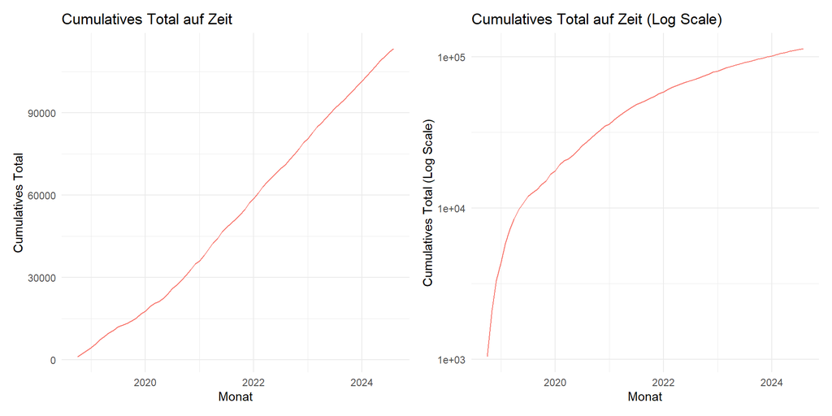

```r
hr01_data <- subset(data, subrubric == "HR01")
hr03_data <- subset(data, subrubric == "HR03")

hr01_counts <- aggregate(id ~ year_month, data = hr01_data, FUN = length)
hr03_counts <- aggregate(id ~ year_month, data = hr03_data, FUN = length)

colnames(hr01_counts) <- c("year_month", "HR01_count")
colnames(hr03_counts) <- c("year_month", "HR03_count")

monthly_counts <- merge(hr01_counts, hr03_counts, by = "year_month", all = TRUE)
monthly_counts[is.na(monthly_counts)] <- 0

monthly_counts$difference <- monthly_counts$HR01_count - monthly_counts$HR03_count

monthly_counts$net_change <- monthly_counts$HR01_count - monthly_counts$HR03_count

monthly_counts$cumulative_total <- cumsum(monthly_counts$net_change)

plot_cumulative <- ggplot(monthly_counts, aes(x = as.Date(paste0(year_month, "-01")))) +
  geom_line(aes(y = cumulative_total, color = "Cumulative Total")) +
  labs(title = "Cumulatives Total auf Zeit",
       x = "Monat",
       y = "Cumulatives Total",
       color = "Legend") +
  theme_minimal() +
  theme(legend.position = "none")

plot_log_scale <- ggplot(monthly_counts, aes(x = as.Date(paste0(year_month, "-01")))) +
  geom_line(aes(y = cumulative_total, color = "Cumulative Total")) +
  scale_y_log10() +
  labs(title = "Cumulatives Total auf Zeit (Log Scale)",
       x = "Monat",
       y = "Cumulatives Total (Log Scale)") +
  theme_minimal() +
  theme(legend.position = "none")

combined_plot <- plot_cumulative + plot_log_scale + plot_layout(ncol = 2)

print(combined_plot)
```

## Monatliche Neueintragungen, Löschungen und Nettozuwachs von Firmen

Das Diagramm zeigt die monatliche Entwicklung von Neueintragungen, Löschungen und dem resultierenden Nettozuwachs.

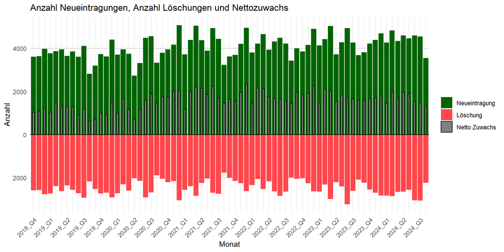

```r
agg_data <- data %>%
  group_by(year_month, subrubric) %>%
  summarise(count = n(), .groups = "drop")

all_months <- unique(agg_data$year_month)
all_subrubrics <- c("HR01", "HR03")
complete_data <- expand.grid(year_month = all_months, subrubric = all_subrubrics) %>%
  left_join(agg_data, by = c("year_month", "subrubric")) %>%
  mutate(count = ifelse(is.na(count), 0, count))

start_of_quarters <- unique(complete_data$year_month[month(as.Date(paste0(complete_data$year_month, "-01"))) %% 3 == 1])

difference_data <- complete_data %>%
  spread(key = subrubric, value = count) %>%
  mutate(NettoZuwachs = HR01 - abs(HR03)) %>%
  select(year_month, NettoZuwachs)

final_data <- complete_data %>%
  left_join(difference_data, by = "year_month") %>%
    mutate(quarter_label = ifelse(year_month %in% start_of_quarters, paste0(substr(year_month, 1, 4), "_Q", quarter(as.Date(paste0(year_month, "-01")))), ""),
         year_month = factor(year_month, levels = unique(year_month)))  # Convert month to a factor

final_data <- final_data %>%
  mutate(count = ifelse(subrubric == "HR03", -count, count))

p <- ggplot(final_data, aes(x = year_month)) +
  geom_col(aes(y = count, fill = subrubric), position = "stack") +
  geom_hline(yintercept = 0, color = "black") +
  scale_y_continuous(labels = abs) +
  scale_x_discrete(labels = final_data$quarter_label) +
  scale_fill_manual(
    values = c("HR01" = "Darkgreen", "HR03" = "#FF474C", "Netto Zuwachs" = "gray50"),
    labels = c("HR01" = "Neueintragung", "HR03" = "Löschung", "Netto Zuwachs" = "Netto Zuwachs")
    ) +
  labs(
    title = "Anzahl Neueintragungen, Anzahl Löschungen und Nettozuwachs",
    x = "Monat",
    y = "Anzahl",
    fill = NULL
  ) +
  theme_minimal() +
  theme(
    axis.text.x = element_text(angle = 45, hjust = 1),
    panel.grid.major.y = element_line(color = "grey80"),
    panel.grid.minor.y = element_blank()
  )

p + geom_col(data = final_data, aes(x = year_month, y = NettoZuwachs, fill = "Netto Zuwachs"), width = 0.3, color = "black", position = position_dodge(width = 0.9))
```

## Kantonale Analyse der Neueintragungen und Löschungen von Firmen

Die Kantone sind nach dem Nettozuwachs (Differenz zwischen Neueintragungen und Löschungen) sortiert, um die Unterschiede im Unternehmenswachstum zwischen den Kantonen aufzuzeigen.

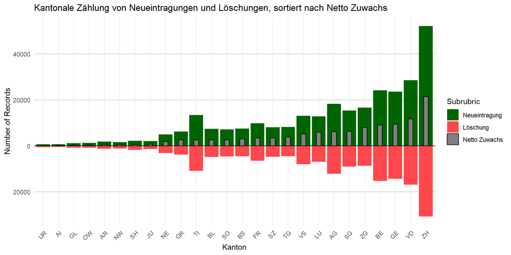

```r
agg_data_kanton <- data %>%
  group_by(kanton, subrubric) %>%
  summarise(count = n(), .groups = "drop")

all_kantons <- unique(agg_data_kanton$kanton)
all_subrubrics <- c("HR01", "HR03")
complete_data_kanton <- expand.grid(kanton = all_kantons, subrubric = all_subrubrics) %>%
  left_join(agg_data_kanton, by = c("kanton", "subrubric")) %>%
  mutate(count = ifelse(is.na(count), 0, count))

difference_data_kanton <- complete_data_kanton %>%
  spread(key = subrubric, value = count) %>%
  mutate(NettoZuwachs = HR01 - abs(HR03)) %>%
  select(kanton, NettoZuwachs)

final_data_kanton <- complete_data_kanton %>%
  left_join(difference_data_kanton, by = "kanton") %>%
  arrange(NettoZuwachs, kanton) %>%  # Break ties by alphabetical order of Kanton
  mutate(kanton = factor(kanton, levels = unique(kanton)))  # Convert kanton to a factor with ordered levels

final_data_kanton <- final_data_kanton %>%
  mutate(count = ifelse(subrubric == "HR03", -count, count))

p <- ggplot(final_data_kanton, aes(x = kanton)) +
  geom_col(aes(y = count, fill = subrubric), position = "stack") +
  geom_hline(yintercept = 0, color = "black") +
  scale_y_continuous(labels = abs) +
  scale_fill_manual(
    values = c("HR01" = "Darkgreen", "HR03" = "#FF474C", "Netto Zuwachs" = "gray50"),
    labels = c("HR01" = "Neueintragung", "HR03" = "Löschung", "Netto Zuwachs" = "Netto Zuwachs")
    ) +
  labs(
    title = "Kantonale Zählung von Neueintragungen und Löschungen, sortiert nach Netto Zuwachs",
    x = "Kanton",
    y = "Number of Records",
    fill = "Subrubric"
  ) +
  theme_minimal() +
  theme(
    axis.text.x = element_text(angle = 45, hjust = 1),
    panel.grid.major.y = element_line(color = "grey80"),
    panel.grid.minor.y = element_blank()
  )

# Add Netto Zuwachs as a separate bar without stacking
p + geom_col(data = final_data_kanton, aes(x = kanton, y = NettoZuwachs, fill = "Netto Zuwachs"), width = 0.3, color = "black", position = position_dodge(width = 0.9))
```

## Prozentuale Verteilung von Neueintragungen und Löschungen nach Kanton

Die Kantone sind nach dem prozentualen Anteil der Neueintragungen geordnet. Hier erkennt man zum Beispiel, dass über den getesteten Zeitraum Kanton Zug prozentuell am meisten Neueintragung hat und Kanton Tessin am wenigsten.

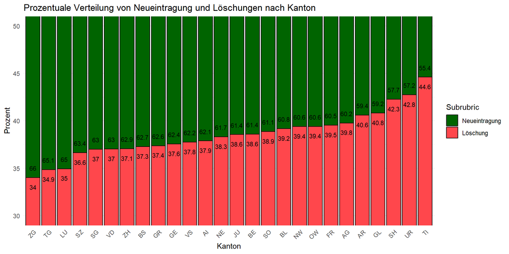

```r
relative_contribution <- complete_data_kanton %>%
  group_by(kanton, subrubric) %>%
  summarise(total_count = sum(count), .groups = 'drop') %>%
  group_by(kanton) %>%
  mutate(percentage = total_count / sum(total_count) * 100)

ordered_kantons <- relative_contribution %>%
  filter(subrubric == "HR01") %>%
  arrange(desc(percentage)) %>%
  pull(kanton)

relative_contribution <- relative_contribution %>%
  mutate(kanton = factor(kanton, levels = ordered_kantons))

dp <- 1
relative_contribution2 <- relative_contribution %>%
  arrange(kanton, subrubric) %>%
  group_by(kanton) %>%
  mutate(y_text = percentage[2] + c(1, -1) * dp)

ggplot(relative_contribution2, aes(x = kanton, y = percentage, fill = subrubric)) +
  geom_col(color = "black") +
  coord_cartesian(ylim = c(30, 50)) +

   geom_text(
    aes(label = round(percentage, 1), y = y_text),
    size = 3,
    color = "black"
  ) +

  labs(
    title = "Prozentuale Verteilung von Neueintragung und Löschungen nach Kanton",
    x = "Kanton",
    y = "Prozent",
    fill = "Subrubric"
  ) +
  scale_fill_manual(
    values = c("HR01" = "Darkgreen", "HR03" = "#FF474C"),
    labels = c("HR01" = "Neueintragung", "HR03" = "Löschung")
    ) +
  theme_minimal() +
  theme(
    axis.text.x = element_text(angle = 45, hjust = 1)
  )
```

## Anzahl Gründungen und Löschungen über die ganze Periode pro Kanton

Diese Grafik zeigt die prozentuale Verteilung von Firmengründungen (Neueintragungen, HR01) und Firmenlöschungen (HR03) für verschiedene Kantone und Jahre. Die obere Grafik bietet eine Gesamtübersicht der Verteilung über den gesamten Zeitraum. Darunter befinden sich die jährlichen Diagramme für die Jahre 2018 bis 2024, in denen die Kantone je nach Anteil der Gründungen sortiert sind.

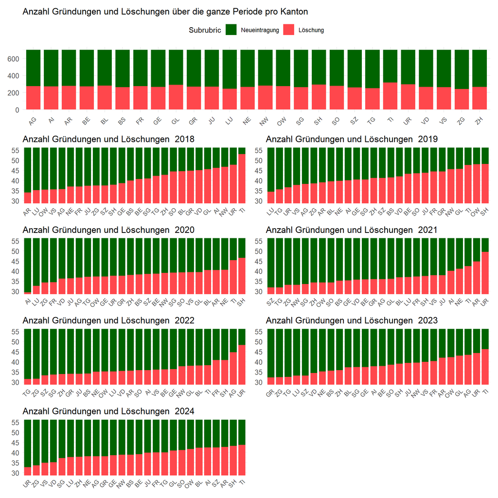

```r
agg_data <- data %>%
  group_by(year, kanton, subrubric) %>%
  summarise(total_count = n(), .groups = 'drop') %>%
  group_by(year, kanton) %>%
  mutate(percentage = total_count / sum(total_count) * 100)

overview_plot <- ggplot(agg_data, aes(x = kanton, y = percentage, fill = subrubric)) +
  geom_bar(stat = "identity", width = 0.8) +
  labs(
    title = "Anzahl Gründungen und Löschungen über die ganze Periode pro Kanton",
    fill = "Subrubric"
  ) +
  scale_fill_manual(
    values = c("HR01" = "Darkgreen", "HR03" = "#FF474C"),
    labels = c("HR01" = "Neueintragung", "HR03" = "Löschung")
    ) +
  theme_minimal() +
  theme(
    axis.text.x = element_text(angle = 45, hjust = 1),
    axis.text.y = element_text(size = 10),
    axis.title.x = element_blank(),  # Remove x-axis title
    axis.title.y = element_blank(),  # Remove y-axis title
    legend.position = "top",  # Legend at the top
    legend.direction = "horizontal"
  )

plots <- list()

for (yr in unique(agg_data$year)) {

   year_data <- agg_data %>% filter(year == yr)

  hr01_order <- year_data %>%
    filter(subrubric == "HR01") %>%
    arrange(desc(percentage)) %>%
    pull(kanton)

  year_data <- year_data %>%
    mutate(kanton = factor(kanton, levels = hr01_order))

   p <- ggplot(year_data, aes(x = kanton, y = percentage, fill = subrubric)) +
    geom_bar(stat = "identity", width = 0.8) +
    labs(
      title = paste('Anzahl Gründungen und Löschungen ', yr)
    ) +
    theme_minimal() +
    theme(
      axis.text.x = element_text(angle = 45, hjust = 1),
      axis.text.y = element_text(size = 10),
      strip.text = element_text(size = 12),
      axis.title.x = element_blank(),
      axis.title.y = element_blank(),
      legend.position = "none"
    ) +

  scale_fill_manual(
    values = c("HR01" = "Darkgreen", "HR03" = "#FF474C"),
    labels = c("HR01" = "Neueintragung", "HR03" = "Löschung")
    ) +
    coord_cartesian(ylim = c(30, 55))

  plots[[yr]] <- p
}

final_plot <- (overview_plot / wrap_plots(plots, ncol = 2)) +
  plot_layout(heights = c(2, 10))

final_plot
```

## Monatliche Eintragungen, Löschungen und Unterschied

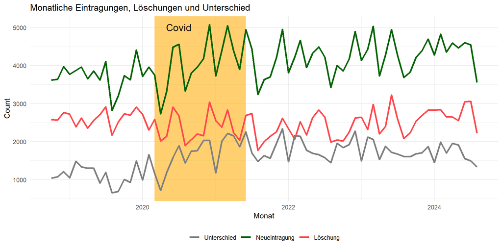

```r
monthly_counts$difference <- monthly_counts$HR01_count - monthly_counts$HR03_count

ggplot(monthly_counts, aes(x = as.Date(paste0(year_month, "-01")))) +
  geom_rect(
    aes(xmin = covid_start, xmax = covid_end, ymin = -Inf, ymax = Inf),
    fill = "orange", alpha = 0.01
  ) +
  geom_line(aes(y = HR01_count, color = "HR01 Count"), size = 1.2) +
  geom_line(aes(y = HR03_count, color = "HR03 Count"), size = 1.2) +
  geom_line(aes(y = difference, color = "Difference"), size = 1.2) +
  scale_y_continuous(name = "Count") +  # Single y-axis for all lines
  scale_color_manual(
    values = c("HR01 Count" = "Darkgreen", "HR03 Count" = "#FF474C", "Difference" = "gray50"),
    labels = c("HR01 Count" = "Neueintragung", "HR03 Count" = "Löschung", "Difference" = "Unterschied")
  ) +
  labs(
    title = "Monatliche Eintragungen, Löschungen und Unterschied",
    x = "Monat",
    color = NULL
  ) +
  annotate("text", x = covid_middle, y = Inf, label = "Covid", vjust = 2, size = 5, color = "black") +
  theme_minimal() +
  theme(legend.position = "bottom")
```

## Anzahl Einträge und Löschungen pro Kanton

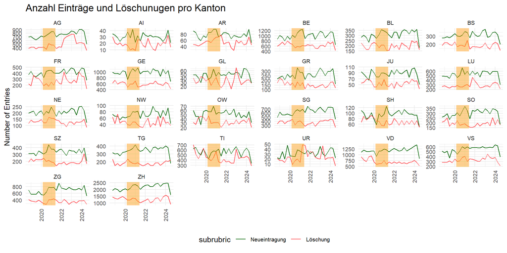

```r
data_summary <- data %>%
  group_by(quarter_year, kanton, subrubric) %>%
  summarise(entries = n(), .groups = "drop")

ggplot(data_summary, aes(x = quarter_year, y = entries, color = subrubric)) +
  geom_line() +
  geom_rect(
    aes(xmin = covid_start, xmax = covid_end, ymin = -Inf, ymax = Inf),
    fill = "orange", alpha = 0.01, color = NA
  ) +
  labs(title = "Anzahl Einträge und Löschunugen pro Kanton", x = NULL, y = "Number of Entries") +
  facet_wrap(~ kanton, scales = "free_y") +
    scale_color_manual(
    values = c("HR01" = "Darkgreen", "HR03" = "#FF474C"),
    labels = c("HR01" = "Neueintragung", "HR03" = "Löschung")
  ) +

  theme_minimal() +
  theme(legend.position = "bottom",
        plot.title = element_text(size = 14),
        axis.title = element_text(size = 10),
        axis.text = element_text(size = 8),
        strip.text = element_text(size = 8),
        legend.text = element_text(size = 8),
        axis.text.x = element_text(angle = 90, vjust = 0.5, hjust = 1))
```

## Anteil der Neueintragungen im Zeitverlauf mit 95%-Konfidenzintervall

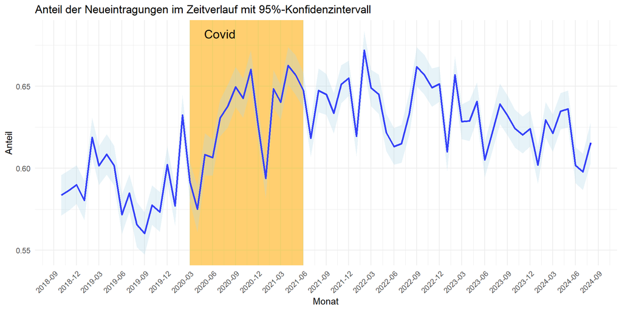

```r
monthly_counts_prop <- data %>%
  group_by(year_month, subrubric) %>%
  summarise(count = n(), .groups = 'drop') %>%
  pivot_wider(names_from = subrubric, values_from = count, values_fill = 0)

monthly_counts_prop <- monthly_counts_prop %>%
  mutate(total = HR01 + HR03,
         proportion = HR01 / total)

alpha <- 0.05  # 95% confidence level

calc_confidence_interval <- function(proportion, total) {
  std_error <- sqrt((proportion * (1 - proportion)) / total)
  lower_bound <- qnorm(alpha / 2, mean = proportion, sd = std_error)
  upper_bound <- qnorm(1 - alpha / 2, mean = proportion, sd = std_error)
  return(c(lower_bound, upper_bound))
}

monthly_counts_prop <- monthly_counts_prop %>%
  rowwise() %>%
  mutate(
    lower_bound = calc_confidence_interval(proportion, total)[1],
    upper_bound = calc_confidence_interval(proportion, total)[2]
  )

monthly_counts_prop$year_month_date <- as.Date(paste0(monthly_counts_prop$year_month, "-01"), format = "%Y-%m-%d")

ggplot(monthly_counts_prop, aes(x = year_month_date, y = proportion)) +
  geom_rect(
    xmin = covid_start, xmax = covid_end, ymin = -Inf, ymax = Inf,
    fill = "orange", alpha = 0.01
  ) +
  geom_line(color = "blue", linewidth = 1) +
  geom_ribbon(aes(ymin = lower_bound, ymax = upper_bound), fill = "lightblue", alpha = 0.3) +
  labs(title = "Anteil der Neueintragungen im Zeitverlauf mit 95%-Konfidenzintervall",
       x = "Monat", y = "Anteil") +
  annotate("text", x = covid_middle, y = Inf, label = "Covid", vjust = 2, size = 5, color = "black") +
  theme_minimal() +
  theme(axis.text.x = element_text(angle = 45, hjust = 1)) +
  scale_x_date(date_labels = "%Y-%m", date_breaks = "3 months")
```

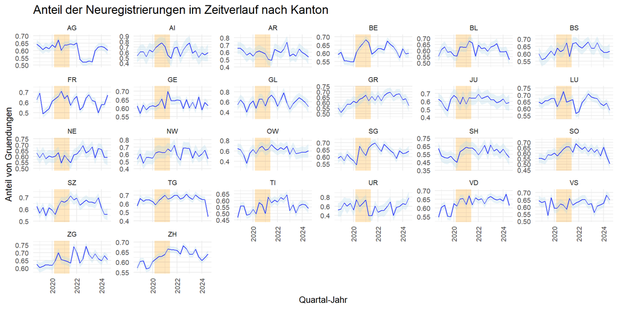

```r
data_summary <- data %>%
  group_by(quarter_year, kanton, subrubric) %>%
  summarise(entries = n(), .groups = "drop") %>%
  pivot_wider(names_from = subrubric, values_from = entries, values_fill = 0) %>%
  mutate(total = HR01 + HR03,
         proportion = HR01 / total)

calc_confidence_interval <- function(proportion, total, alpha = 0.05) {
  std_error <- sqrt((proportion * (1 - proportion)) / total)  # standard error
  lower_bound <- proportion - qnorm(1 - alpha / 2) * std_error
  upper_bound <- proportion + qnorm(1 - alpha / 2) * std_error
  return(c(lower_bound, upper_bound))
}

data_summary <- data_summary %>%
  rowwise() %>%
  mutate(
    lower_bound = calc_confidence_interval(proportion, total)[1],
    upper_bound = calc_confidence_interval(proportion, total)[2]
  ) %>%
  ungroup()

ggplot(data_summary, aes(x = quarter_year)) +
  # Add Covid period shading
  geom_rect(
    aes(xmin = covid_start, xmax = covid_end, ymin = -Inf, ymax = Inf),
    fill = "orange", alpha = 0.01, color = NA
  ) +
  # Line for proportion of HR01
  geom_line(aes(y = proportion), color = "blue", linetype = "solid") +
  # Confidence intervals as ribbon
  geom_ribbon(aes(ymin = lower_bound, ymax = upper_bound), fill = "lightblue", alpha = 0.3) +
  scale_y_continuous(name = "Anteil von Gruendungen") +
  facet_wrap(~ kanton, scales = "free_y") +
  labs(title = "Anteil der Neuregistrierungen im Zeitverlauf nach Kanton",
       x = "Quartal-Jahr", y = "Anteil von Gründungen") +
  theme_minimal() +
  theme(legend.position = "none",
        plot.title = element_text(size = 14),
        axis.title = element_text(size = 10),
        axis.text = element_text(size = 8),
        strip.text = element_text(size = 8),
        axis.text.x = element_text(angle = 90, vjust = 0.5, hjust = 1))
```

## Lineare Regression der täglichen Neuregistrierungen in Abhängigkeit von Löschungen

Diese Grafik zeigt eine lineare Regression der täglichen **HR01-Neuregistrierungen** in Abhängigkeit von den täglichen **HR03-Löschungen**. Es gibt eine leichte positive Korrelation, was bedeutet, dass an Tagen mit mehr Löschungen tendenziell auch mehr Neuregistrierungen stattfinden. Die Streuung der Punkte deutet jedoch darauf hin, dass diese Beziehung schwach ist.

```r
hr01_counts_daily <- hr01_data %>%
  group_by(date) %>%
  summarise(HR01_count = n())

hr03_counts_daily <- hr03_data %>%
  group_by(date) %>%
  summarise(HR03_count = n())

daily_counts <- merge(hr01_counts_daily, hr03_counts_daily, by = "date", all = TRUE)
daily_counts[is.na(daily_counts)] <- 0

daily_counts$difference <- daily_counts$HR01_count - daily_counts$HR03_count

lm_model_daily <- lm(HR01_count ~ HR03_count, data = daily_counts)

summary(lm_model_daily)
```

```
##
## Call:
## lm(formula = HR01_count ~ HR03_count, data = daily_counts)
##
## Residuals:
##      Min       1Q   Median       3Q      Max
## -163.097  -20.844    0.524   23.090  112.582
##
## Coefficients:
##              Estimate Std. Error t value Pr(>|t|)
## (Intercept) 127.02427    3.20588   39.62   <2e-16 ***
## HR03_count    0.56261    0.02617   21.50   <2e-16 ***
## ---
## Signif. codes:  0 '***' 0.001 '**' 0.01 '*' 0.05 '.' 0.1 ' ' 1
##
## Residual standard error: 34.26 on 1499 degrees of freedom
## Multiple R-squared:  0.2356, Adjusted R-squared:  0.2351
## F-statistic: 462.1 on 1 and 1499 DF,  p-value: < 2.2e-16
```

```r
tidy_results_daily <- tidy(lm_model_daily, conf.int = TRUE)
tidy_results_daily
```

```
## # A tibble: 2 × 7
##   term        estimate std.error statistic   p.value conf.low conf.high
##   <chr>          <dbl>     <dbl>     <dbl>     <dbl>    <dbl>     <dbl>
## 1 (Intercept)  127.       3.21        39.6 1.68e-235  121.      133.
## 2 HR03_count     0.563    0.0262      21.5 1.44e- 89    0.511     0.614
```

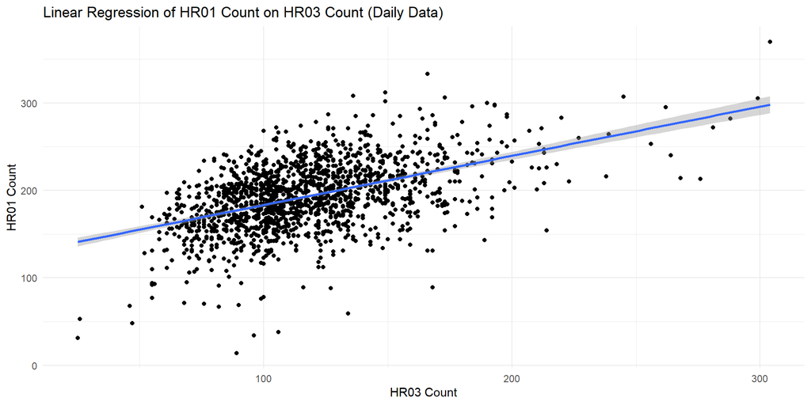

```r
ggplot(daily_counts, aes(x = HR03_count, y = HR01_count)) +
  geom_point() +
  geom_smooth(method = "lm", se = TRUE) +
  labs(title = "Linear Regression of HR01 Count on HR03 Count (Daily Data)",
       x = "HR03 Count",
       y = "HR01 Count") +
  theme_minimal()
```

## Regression von Löschungen und Neueintragungen über die Zeit

In dieser Grafik sind die täglichen **HR01-Neuregistrierungen** (grün) und **HR03-Löschungen** (rot) über die Zeit dargestellt, zusammen mit ihren jeweiligen Regressionslinien. Die flachen Steigungen der Regressionslinien zeigen, dass es über die Zeit nur einen geringen Trend in beiden Richtungen gibt. Die Anzahl der Neueintragungen ist leicht steigend, während die Löschungen weitgehend konstant bleiben.

```r
count_per_date <- data %>%
  group_by(date, subrubric) %>%
  summarise(count = n())
```

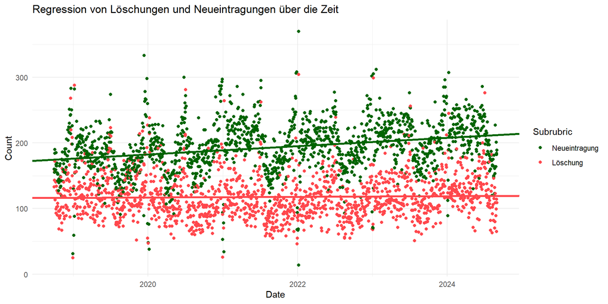

```r
hr03_data <- count_per_date %>% filter(subrubric == "HR03")
hr01_data <- count_per_date %>% filter(subrubric == "HR01")

fit_hr03 <- lm(count ~ date, data = hr03_data)
fit_hr01 <- lm(count ~ date, data = hr01_data)

intercept_hr03 <- coef(fit_hr03)[1]
slope_hr03 <- coef(fit_hr03)[2]

intercept_hr01 <- coef(fit_hr01)[1]
slope_hr01 <- coef(fit_hr01)[2]

ggplot(count_per_date, aes(x = date, y = count, color = subrubric)) +
  geom_point() +
  geom_abline(intercept = intercept_hr03, slope = slope_hr03, color = '#FF474C', size = 1.2, linetype = "solid") +
  geom_abline(intercept = intercept_hr01, slope = slope_hr01, color = "Darkgreen", size = 1.2, linetype = "solid") +
  labs(title = "Regression von Löschungen und Neueintragungen über die Zeit",
       x = "Date",
       y = "Count",
       color = "Subrubric") +
    scale_color_manual(
    values = c("HR01" = "Darkgreen", "HR03" = "#FF474C"),
    labels = c("HR01" = "Neueintragung", "HR03" = "Löschung")
  ) +
  theme_minimal()
```

## Monatliche Löschungen- und Neuregistrierungen-Zählungen nach Jahr

Die beiden Grafiken zeigen die monatlichen Zählungen für **HR03-Löschungen** und **HR01-Neuregistrierungen** von 2020 bis 2024. Die Farben gehen von Blau (ältere Jahre) zu Rot (aktuellere Jahre), was den Jahresverlauf veranschaulicht.

- **HR03-Löschungen**: Es zeigt sich eine gewisse Saisonalität, insbesondere in den Sommermonaten, wo oft ein Anstieg der Löschungen zu sehen ist.
- **HR01-Neuregistrierungen**: Auch hier gibt es Schwankungen, mit Höchstständen im Frühjahr und Frühsommer, und ein Anstieg in den letzten Monaten des Jahres.

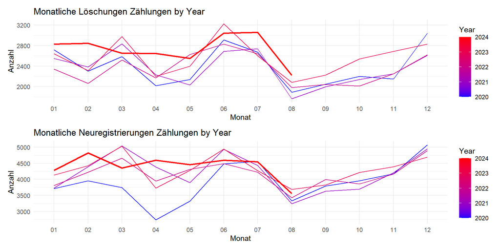

```r
hr03_data <- subset(data, subrubric == "HR03" & year >= 2020)
hr03_counts <- hr03_data %>%
  group_by(year, month) %>%
  summarise(count = n(), .groups = 'drop')

hr01_data <- subset(data, subrubric == "HR01" & year >= 2020)
hr01_counts <- hr01_data %>%
  group_by(year, month) %>%
  summarise(count = n(), .groups = 'drop')

line_size_current <- 1
line_size_other <- 0.5

plot_hr03 <- ggplot(hr03_counts, aes(x = month, y = count, group = year, color = as.numeric(year))) +
  geom_line(aes(size = ifelse(year == current_year, line_size_current, line_size_other))) +
  labs(title = "Monatliche Löschungen Zählungen by Year",
       x = "Monat",
       y = "Anzahl",
       color = "Year") +
  scale_x_discrete(limits = sprintf("%02d", 1:12)) +
  theme_minimal() +
  scale_size_identity() +
  scale_color_gradient(low = "blue", high = "red") +
  guides(size = "none")

plot_hr01 <- ggplot(hr01_counts, aes(x = month, y = count, group = year, color = as.numeric(year))) +
  geom_line(aes(size = ifelse(year == current_year, line_size_current, line_size_other))) +
  labs(title = "Monatliche Neuregistrierungen Zählungen by Year",
       x = "Monat",
       y = "Anzahl",
       color = "Year") +
  scale_x_discrete(limits = sprintf("%02d", 1:12)) +
  theme_minimal() +
  scale_size_identity() +
  scale_color_gradient(low = "blue", high = "red") +
  guides(size = "none")

combined_plot <- plot_hr03 + plot_hr01 + plot_layout(ncol = 1, heights = c(1, 1))

print(combined_plot)
```